# Assignment 4- MA710 Dataminers

## 1. Introduction

The data we are working on is provided by the U.S department of Education. The data set contains information of the College Scorecard, federal financial aid and students’ earning records. The data set can help to understand the information of getting federal financial and have insights on the school performance as well as students’ long term development. The data set contains 1743 variables which are organized into 10 categories. The categories cover a range of topics:

- Root - basic information such as School Id and location.
- School - basic descriptive information such as degree types, number of branches, Carnegie classification, Public or Private etc.
- Academics - types of academics available at the school.
- Admissions - admission statistics such as acceptance rate and SAT/ACT scores.
- Student - descriptions of the students including the number of undergraduate students, part-time or full-time students, share of first generation students.
- Cost - information cost for students such as average cost of attendance, tuition and fees, and average net price for institutions by income level.
- Aid - the amount of debt a student can take on while attending the college, typical monthly loan payments, and the percentage of Pell Grant Recipients.
- Repayment - descriptions of how successful students are at repaying their debts which is measured by cohort default rate and repayment rate.
- Completion - information on the completion and retention rates for first time and full time students.
- Earnings - statistics on average and median earnings as well as share of former students’ earning more than $25,000.

Based on the information provided by the data set,the descriptive analysis is performed.

## 2.Goals

“Private colleges vs. public colleges”. There is a face-off that is been ongoing for many years. The major difference between public and private colleges lies in how they are funded. Public colleges are funded mostly by state governments, whereas private colleges rely heavily on private contributions, donations and tuition. The goal of our analysis is to build a model which predicts whether an institution is public or private based on a numer of variables describing the colleges. The variables we will use include percentage of first time college graduates, percentage of female students, types of degree awarded, annual cost of attendance.

## 3.DataSet Description

There are 21 variables that we are interested in. The variables name, type and descriptions are listed below.

*For variable `NPT4_PRIV` and `NPT4_PUB`, they includes tuition, supplies, living expenses minus the average grand or scholarship; the cost is calculated for full-time, fist-time, degree and certificate seeking undergraduates

| Variables | Type | Descriptions |
| --- | --- | --- |
| Type | FACTOR | Public or Private Institution |
| Family_Inc | NUMERIC | Average family income in real 2015 dollars ($) |
| Female | NUMERIC | Percentage of female students |
| Married | NUMERIC | Percentage of married students |
| DEP_STAT_PCT_IND | NUMERIC | Percentage of financially independent students |
| First_Gen | NUMERIC | Percentage of first generation students |
| NPT4_PRIV | NUMERIC | Average annual cost of attendance a Private college ($) |
| NPT4_PUB | NUMERIC | Average annual cost of attendance a Public college ($) |
| NUMBRANCH | NUMERIC | Number of Branch Campuses |
| PCIP01 | NUMERIC | Percentage of degrees awarded in Agriculture , Agriculture Operations, And Related Sciences |
| PCIP03 | NUMERIC | Percentage of degrees awarded in Natural Resources And Conservation |
| PCIP04 | NUMERIC | Percentage of degrees awarded in Architecture And Related Services |
| PCIP05 | NUMERIC | Percentage of degrees awarded in Area, Ethnic, Cultural, Gender, And Group Studies |
| PCIP09 | NUMERIC | Percentage of degrees awarded in Communication, Journalism, And Related Programs |
| PCIP10 | NUMERIC | Percentage of degrees awarded in Communications Technologies/Technicians And Support Services |
| CDR3 | NUMERIC | Three-year cohort default rate |
| CDR3_DENOM | NUMERIC | Number of students in the cohort for the three-year cohort default rate |
| PCTPELL | NUMERIC | Percentage of undergraduates who receive a Pell Grant |
| PCTFLOAN | NUMERIC | Percent of all federal undergraduate students receiving a federal student loan |
| DEBT_N | NUMERIC | The number of students in the median debt completers cohort |
| CUML_DEBT_N | NUMERIC | Number of students in the cumulative loan debt cohort |

## 4.Objectives

Our main goal of the project is to predict whether an institution is public or private. Based on this goal, we will define a number of objectives:

- Apply k nearest neighbour and decision tree model algorithms for predicting the type of institution
- Fine tune the parameters of each of the algorithms in order to improve the prediction power
- Compare the results between the two algorithms
- Investigate which of the used variables are more important in determining the type of college

## 5.Data Preparation

Before applying both predictive algorithms, we will perform some data cleaning and preparation.

### 5.1 Loading libraries

We will load the `dplyr` package that contains functions for data manipulation using data frames. It allows us to order rows, select rows, select variables, modify variables and summarize variables. We will also load the `ggplot2` package which is a powerful plotting package that creates elegant and complex plots in R. The `magrittr` library is loaded for the piping operator `%>%`. The `readr` library is loaded to read in the csv file.

```r
library(dplyr)
library(ggplot2)
library(magrittr)
library(readr)
library(caTools)
```

Then we read in the csv file `MERGED2014_15_PP.csv` into the data frame `csb.df` using the `read_csv` function of the `readr` package.

```r
csb.df = read_csv(paste0('C:/Users/Chengdong Liang/Desktop/MA 710/Assignment 1/CollegeScorecard_Raw_Data/', 'MERGED2014_15_PP.csv'))
```

### 5.2 Data cleaning and variable modification

For our analysis, we wish to include only those institutions which are currently operating. So we filter the rows to keep those which have `CURROPER` equal to 1.

```r
csb.df %>%
  filter(CURROPER ==1) %>%
  {.} -> csbop.df
```

The new data frame `csbop.df` consists of only currently operating institutions. Based on our decision to select certain variables, we will use the `SELECT` command from `dply` package to create a smaller data frame which contains only the variables of interest.

```r
csbop.df %>%
  select(CONTROL, FAMINC, FEMALE, MARRIED,DEP_STAT_PCT_IND, FIRST_GEN, NPT4_PRIV, NPT4_PUB, NUMBRANCH,
         PCIP01,PCIP03,PCIP04,PCIP05,PCIP09,PCIP10, CDR3, CDR3_DENOM, PCTPELL, PCTFLOAN,
          DEBT_N, CUML_DEBT_N) %>%
  {.} -> csb.vars.df
```

The resulting data frame `csb.vars.df` contains only the selected variables. Next we get a glimpse of this new data frame `csb.vars.df`. The `glimpse` function allows us to see all the columns in the data frame.

```r
glimpse(csb.vars.df)
```

```
## Observations: 6,893
## Variables: 21
## $ CONTROL          <int> 1, 1, 2, 1, 1, 1, 1, 1, 1, 1, 2, 1, 2, 3, 1, ...
## $ FAMINC           <chr> "30235.73401", "49731.07607", "19862.04352", ...
## $ FEMALE           <chr> "0.5262741999", "0.6323896753", "0.6465256798...
## $ MARRIED          <chr> "0.0165942315", "0.1034554538", "0.2386706949...
## $ DEP_STAT_PCT_IND <chr> "0.1295930462", "0.3116153206", "0.8942598187...
## $ FIRST_GEN        <chr> "0.3940338379", "0.3571588618", "0.6024096386...
## $ NPT4_PRIV        <chr> "NULL", "NULL", "12992", "NULL", "NULL", "NUL...
## $ NPT4_PUB         <chr> "15229", "14789", "NULL", "18596", "11110", "...
## $ NUMBRANCH        <int> 1, 1, 1, 1, 1, 1, 1, 1, 1, 1, 1, 1, 1, 16, 1,...
## $ PCIP01           <chr> "0.0424", "0", "0", "0", "0", "0", "0", "0", ...
## $ PCIP03           <chr> "0.0191", "0", "0", "0", "0", "0.0033", "0", ...
## $ PCIP04           <chr> "0.0169", "0", "0", "0", "0", "0", "0", "0", ...
## $ PCIP05           <chr> "0", "0.0024", "0", "0", "0", "0.0024", "0", ...
## $ PCIP09           <chr> "0", "0.0485", "0", "0.0289", "0.087", "0.115...
## $ PCIP10           <chr> "0.0487", "0", "0", "0", "0", "0", "0", "0", ...
## $ CDR3             <chr> "0.172", "0.062", "0.122", "0.061", "0.156", ...
## $ CDR3_DENOM       <chr> "1895", "3937", "344", "1513", "2137", "5023"...
## $ PCTPELL          <chr> "0.7356", "0.346", "0.6801", "0.3072", "0.734...
## $ PCTFLOAN         <chr> "0.8284", "0.5214", "0.7795", "0.4596", "0.75...
## $ DEBT_N           <chr> "2887", "6051", "412", "2523", "3931", "9396"...
## $ CUML_DEBT_N      <chr> "2887", "6051", "412", "2523", "3931", "9396"...
```

To convert the class of these variables to the desired class, we use the functions `as.numeric` and `as.factor`, which convert the class variables to `numeric` and `factor` respectively.The code below uses the `MUTATE` command from the `dplyr` library to alter variables of the input data frame `csb.vars.df` and returns the modified data frame `csb.class.df`.

```r
csb.vars.df %>%
  mutate(
         CONTROL    = as.factor(CONTROL),
         FAMINC  = as.numeric(FAMINC),
         FEMALE = as.numeric(FEMALE),
         MARRIED  = as.numeric(MARRIED),
         DEP_STAT_PCT_IND = as.numeric(DEP_STAT_PCT_IND),
         FIRST_GEN = as.numeric(FIRST_GEN),
         NPT4_PRIV = as.numeric(NPT4_PRIV),
         NPT4_PUB = as.numeric(NPT4_PUB),
         NUMBRANCH = as.numeric(NUMBRANCH),
         PCIP01=as.numeric(PCIP01),
         PCIP03=as.numeric(PCIP03),
         PCIP04=as.numeric(PCIP04),
         PCIP05=as.numeric(PCIP05),
         PCIP09=as.numeric(PCIP09),
         PCIP10=as.numeric(PCIP10),
         CDR3 = as.numeric(CDR3),
         CDR3_DENOM  = as.numeric(CDR3_DENOM),
         PCTPELL = as.numeric(PCTPELL),
         PCTFLOAN = as.numeric(PCTFLOAN),
         DEBT_N = as.numeric(DEBT_N),
         CUML_DEBT_N = as.numeric(CUML_DEBT_N)) %>%
         {.} -> csb.var.df
```

The next step is to check for the percentage of NA (missing) values for the above range of variables. This is accomplished by first adding the number of NA values for each variable, dividing it by the `length` of the variable(total number of observations) and multiplying by 100 to convert it into a percentage.

Since we would like to apply this function to a range of variables, we use the `summarise_at` command. `summarise_at` takes the set of columns to be summarized as the first parameter which in our case would be all columns and the function to be applied to them as the second parameter.

```r
csb.var.df %>%
  summarise_at(.cols = vars(),
               .funs = function(x) sum(is.na(x))/length(x))*100
```

```
##   CONTROL   FAMINC   FEMALE  MARRIED DEP_STAT_PCT_IND FIRST_GEN NPT4_PRIV
## 1       0 4.163644 17.53953 15.31989         9.879588  14.08675  41.33179
##   NPT4_PUB NUMBRANCH   PCIP01   PCIP03   PCIP04   PCIP05   PCIP09   PCIP10
## 1 72.40679         0 8.907587 8.907587 8.907587 8.907587 8.907587 8.907587
##       CDR3 CDR3_DENOM  PCTPELL PCTFLOAN  DEBT_N CUML_DEBT_N
## 1 12.99869   12.99869 9.226752 9.226752 12.4329     12.4329
```

We can observe from the output that `FAMINC` has 4.16% missing values, `MARRIED` has 15.32% missing values and so on. Since some of the algorithms we will apply do not accept missing values and we would like to compare the algorithms based on their performance, we will remove the missing values. But before we perform the removal, we will make a number of additional variable transformations.

```r
csb.var.df %>%
  mutate(CONTROL = ifelse((CONTROL==2|CONTROL==3),"Public","Private")) %>%
  mutate(CONTROL    = as.factor(CONTROL)) %>%
  {.} ->csb.new.df
```

The variables `NTP4_PRIV` and `NTP4_PUB` describes the average net price of either Public or Private colleges, and are complementing each other. For this reason, we will build a new variable `NPT4` which describes the average net price for both public and private colleges.

To do this, we first define a function `replace_na_values` which takes the variable as the input and by looping over the entire length of the variable, replaces each NA values by 0. We call this function on our two variables `NPT4_PRIV` and `NPT4_PUB`. Then we create a new variable `NPT4` by adding the two variables `NPT4_PRIV` and `NPT4_PUB` using the `MUTATE` command.

```r
  replace_na_values <- function (variable){
    for (i in 1:length(variable)){
      if (is.na(variable[i])){
        variable[i] = 0
      }
    }
    return (variable)
  }

csb.new.df %>%
  mutate(NPT4 = replace_na_values(NPT4_PRIV) + replace_na_values(NPT4_PUB)) %>%
  {.} -> csb.new.df

csb.new.df %>% select(-NPT4_PRIV, -NPT4_PUB) %>% {.} -> csb.new.df
```

After we have performed the transformation of some of the variables, we will remove the observations with missing values.

```r
require(IDPmisc)

csb.omit.na.df = NaRV.omit(csb.new.df)
```

Since the names of these variables are not easy to understand, we rename them using the `rename` function of the `dplyr` package.

```r
csb.omit.na.df %>%
  rename(Type = CONTROL,
         Family_Inc = FAMINC,
         Female_perc = FEMALE,
         Married_perc = MARRIED,
         Fin_Indep_perc = DEP_STAT_PCT_IND,
         First_Gen_perc = FIRST_GEN,
         Cost = NPT4,
         Num_Branches = NUMBRANCH,
         Agric_deg_perc = PCIP01,
         Nature_deg_perc = PCIP03,
         Architect_deg_perc = PCIP04,
         Cultural_deg_perc = PCIP05,
         Communication_deg_perc = PCIP09,
         Technology_deg_perc= PCIP10,
         Cohort_def_rate = CDR3,
         Num_students_cohort = CDR3_DENOM,
         Pell_grant_perc = PCTPELL,
         Deg_loan_perc = PCTFLOAN,
         Num_stud_median_debt =  DEBT_N,
         Num_stud_cum_debt = CUML_DEBT_N) %>%
         {.} -> csb.ren.df
```

The data frame `csb.ren.df` contains our final set of variables, ready for further analysis.

### 5.3 Creating training and test datasets

To split the dataset into training and test sets, we first set a seed so that we can get the same sequence of random numbers whenever we supply the same seed in the random number generator.

```r
set.seed(123)
```

Then we use the `sample.split()` fucntion which is part of `caTools` package. The split ratio is 0.8 which implies that 80% of observations go in the train set and the the rest 20% in the test set. The code below will create a new column `new` in the dataset that will have the 80% of rows having TRUE values and 20% with FALSE values.

```r
csb.ren.df$new=sample.split(csb.ren.df,SplitRatio=0.8)
```

Next we create a `train` dataframe which is a subset of the original dataframe `csb.ren.df` containing only those observations that have TRUE values for the new column.

```r
train=subset(csb.ren.df, csb.ren.df$new==TRUE)
```

We also create a `test` dataframe which is a subset of the original dataframe `csb.ren.df` containing only those observations that have FALSE values for the new column.

```r
test=subset(csb.ren.df, csb.ren.df$new==FALSE)
```

In the next step, we drop the `new` column from the `train` and `test` dataframes.

```r
train %>%
  select(-new) %>%
{.} -> train
```

```r
test %>%
  select(-new) %>%
{.} -> test
```

Finally, we have the `train` and `test` dataframes ready for fitting the models.

## 6. Decision Trees

The following libraries are loaded for fitting the decision tree.

```r
library(rpart)
library(rpart.plot)
library(rattle)
```

### 6.1 Building the tree

The code below uses the `rpart` function to fit a decision tree to the `train` dataframe, with `Type` as the categorical target variable and all other variables as the predictors, using the default control parameters.

```r
treefit <- rpart(Type ~ . - Type, data = train, method = "class", control = rpart.control())
```

Next we display the results for the classification tree.

```r
print(treefit)
```

```
## n= 3440
##
## node), split, n, loss, yval, (yprob)
##       * denotes terminal node
##
##  1) root 3440 1252 Public (0.36395349 0.63604651)
##    2) Cost< 11610 1125  275 Private (0.75555556 0.24444444)
##      4) Female_perc< 0.7068747 929  122 Private (0.86867600 0.13132400)
##        8) Fin_Indep_perc< 0.7108449 843   61 Private (0.92763938 0.07236062)
##         16) Pell_grant_perc< 0.7973 804   28 Private (0.96517413 0.03482587) *
##         17) Pell_grant_perc>=0.7973 39    6 Public (0.15384615 0.84615385) *
##        9) Fin_Indep_perc>=0.7108449 86   25 Public (0.29069767 0.70930233) *
##      5) Female_perc>=0.7068747 196   43 Public (0.21938776 0.78061224) *
##    3) Cost>=11610 2315  402 Public (0.17365011 0.82634989)
##      6) Fin_Indep_perc< 0.338182 699  288 Public (0.41201717 0.58798283)
##       12) Num_stud_median_debt>=2540.5 273   43 Private (0.84249084 0.15750916)
##         24) Cost< 22200 229    5 Private (0.97816594 0.02183406) *
##         25) Cost>=22200 44    6 Public (0.13636364 0.86363636) *
##       13) Num_stud_median_debt< 2540.5 426   58 Public (0.13615023 0.86384977) *
##      7) Fin_Indep_perc>=0.338182 1616  114 Public (0.07054455 0.92945545)
##       14) Cost< 16673 504   94 Public (0.18650794 0.81349206)
##         28) Pell_grant_perc< 0.48645 139   67 Public (0.48201439 0.51798561)
##           56) Female_perc< 0.6851574 78   17 Private (0.78205128 0.21794872) *
##           57) Female_perc>=0.6851574 61    6 Public (0.09836066 0.90163934) *
##         29) Pell_grant_perc>=0.48645 365   27 Public (0.07397260 0.92602740) *
##       15) Cost>=16673 1112   20 Public (0.01798561 0.98201439) *
```

```r
printcp(treefit)
```

```
##
## Classification tree:
## rpart(formula = Type ~ . - Type, data = train, method = "class",
##     control = rpart.control())
##
## Variables actually used in tree construction:
## [1] Cost                 Female_perc          Fin_Indep_perc
## [4] Num_stud_median_debt Pell_grant_perc
##
## Root node error: 1252/3440 = 0.36395
##
## n= 3440
##
##         CP nsplit rel error  xerror     xstd
## 1 0.459265      0   1.00000 1.00000 0.022539
## 2 0.087859      1   0.54073 0.57268 0.019028
## 3 0.074681      2   0.45288 0.45367 0.017393
## 4 0.028754      4   0.30351 0.34425 0.015508
## 5 0.025559      5   0.27476 0.30112 0.014634
## 6 0.021565      6   0.24920 0.29313 0.014462
## 7 0.011715      7   0.22764 0.25559 0.013607
## 8 0.010000     10   0.19249 0.24601 0.013375
```

The `cptable` above provides a brief summary of the overall fit of the model. The table is printed from the smallest tree (no splits) to the largest one (10 splits). Looking at the table, we see that the best tree has 10 splits with the lowest cp of 0.01 based on cross-validation with the smalles cross-validation error of 0.24601. We retrieve this value from the table.

```r
bestcp <- treefit$cptable[which.min(treefit$cptable[,"xerror"]), "CP"]
```

### 6.2 Pruning the tree

Now we prune the tree using this “best” complexity parameter.

```r
fit.pruned <- prune(treefit, cp = bestcp)
```

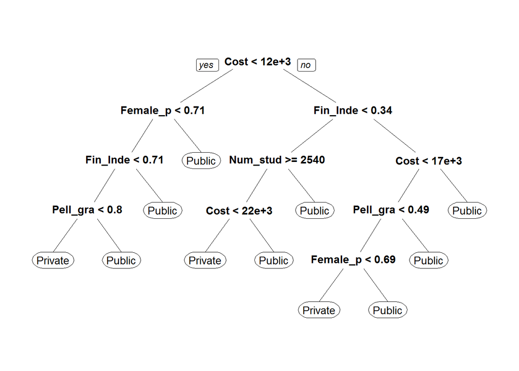

```r
prp(fit.pruned)
```

### 6.3 Predicting on Test dataset

To assess the performance of the classification tree, we predict on the `test` dataframe using the `predict` function and saving the output in `out` dataframe.

```r
out <- predict(fit.pruned, test)
```

Then we look at the first six rows of the `out` dataframe.

```r
head(out)
```

```
##     Private     Public
## 1 0.9651741 0.03482587
## 2 0.9651741 0.03482587
## 3 0.9651741 0.03482587
## 4 0.9651741 0.03482587
## 5 0.1361502 0.86384977
## 6 0.1538462 0.84615385
```

The output tells us that each row contains the predcited probabilities for each value of the target variable `Type`. For instance, we can see that predicted probability for the first observation to be classified as a Private college is 0.9651 and to be a Public college is 0.03482. For each observation, we’ll need to find which class has the highest probability and then assign that class to the observation.

To do this, we pass `which.max` to apply, with a second argument of 1 to indicate we want to apply the function to each row.

```r
confusion= table(apply(out,1,which.max),test$Type)
confusion
```

```
##
##     Private Public
##   1     265     20
##   2      46    529
```

The output above shows the confusion matrix for the classification tree. From the output we see that 265 Private colleges and 529 Public colleges were classified correctly. The code below is used to calculate the misclassification rate.

```r
sum(confusion[row(confusion) != col(confusion)]) / sum(confusion)
```

```
## [1] 0.07674419
```

The output tells us that the 7.67% of the observations were predicted incorrectly. To reduce the misclassification rate, we tune the hyperparameters of the model.

### 6.4 Changing control parameters

We change the default parameters.

```r
treefit1 <- rpart(Type ~ . - Type, data = train, control = rpart.control(minsplit=10,cval=15,cp=0, minbucket=20))
out1 <- predict(treefit1, test)
confusion_1 = table(apply(out1,1,which.max),test$Type)
sum(confusion_1[row(confusion_1) != col(confusion_1)]) / sum(confusion_1)
```

```
## [1] 0.06976744
```

On changing the parameters, we are able to successfully reduce the misclassification rate from 7.67 % to 6.98 %.

## 7. Decision Trees - Part II

We would like to modify the hyperparameters of decision tree model further to tune the model more specifically.

### 7.1 Building the tree

The code below uses the `rpart` function to fit a decision tree to the `train` dataframe, with `Type` as the categorical target variable and all other variables as the predictors. For this time, we start by using the arguments `minsplit=0` and `cp=0` as the setting of the `control` paramters.

```r
tree2fit <- rpart(Type ~ . - Type, data = train, method = "class", control = rpart.control(minsplit=0, cp=0))
```

Next we select the appropriate CP value by choosing the lowest level with the minumum `xerror` value.

```r
printcp(tree2fit)
```

```
##
## Classification tree:
## rpart(formula = Type ~ . - Type, data = train, method = "class",
##     control = rpart.control(minsplit = 0, cp = 0))
##
## Variables actually used in tree construction:
##  [1] Agric_deg_perc         Architect_deg_perc     Cohort_def_rate
##  [4] Communication_deg_perc Cost                   Cultural_deg_perc
##  [7] Deg_loan_perc          Family_Inc             Female_perc
## [10] Fin_Indep_perc         First_Gen_perc         Married_perc
## [13] Nature_deg_perc        Num_Branches           Num_stud_median_debt
## [16] Num_students_cohort    Pell_grant_perc        Technology_deg_perc
##
## Root node error: 1252/3440 = 0.36395
##
```

[output cut: 29 more lines]

We could also plot the cp value with X-val Relative Error as below:

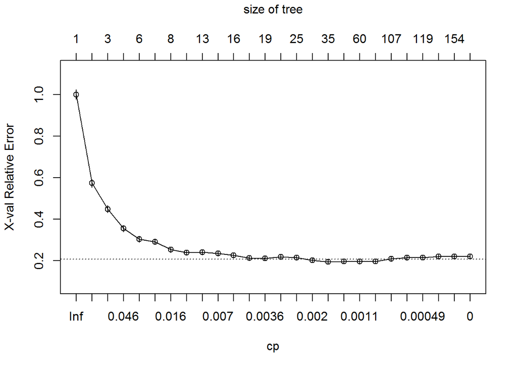

```r
plotcp(tree2fit)
```

As we can see, the `xerror` drops dramatically till the ninth split and then decreases slowly till the twentieth split.

As follow, We need to retrieve the `cp` value with the lowest `xerror` from the table:

```r
bestcp <-tree2fit$cptable[which.min(tree2fit$cptable[,"xerror"]), "CP"]
```

### 7.2 Pruning the tree

Now we prune the tree using this “best” complexity parameter.

```r
fit.pruned <- prune(tree2fit, cp = bestcp)
```

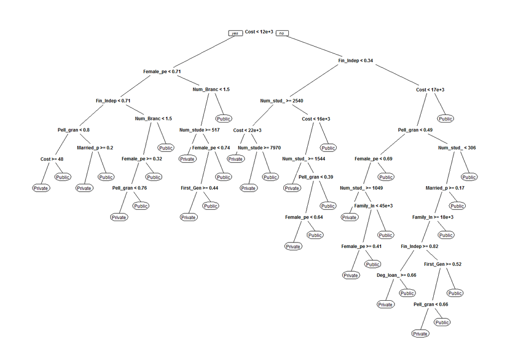

```r
prp(fit.pruned)
```

### 7.3 Predicting on Test dataset

To assess the performance of the classification tree, we predict on the `test` dataframe using the `predict` function and saving the output in `out` dataframe.

```r
out <- predict(fit.pruned, test)
```

Then we look at the first six rows of the `out` dataframe.

```r
head(out)
```

```
##      Private     Public
## 1 0.97848101 0.02151899
## 2 0.97848101 0.02151899
## 3 0.97848101 0.02151899
## 4 0.97848101 0.02151899
## 5 0.04518072 0.95481928
## 6 0.05714286 0.94285714
```

The output tells us that each row contains the predicted probabilities for each value of the target variable `Type`. For instance, we can see that predicted probability for the first observation to be classified as a Private college is 0.97848101 and to be a Public college is 0.02151899. For each observation, we’ll need to find which class has the highest probability and then assign that class to the observation.

To do this, we pass `which.max` to apply, with a second argument of 1 to indicate we want to apply the function to each row.

```r
confusion= table(apply(out,1,which.max),test$Type)
confusion
```

```
##
##     Private Public
##   1     278     22
##   2      33    527
```

The output above shows the confusion matrix for the classification tree. From the output we see that 278 Private colleges and 527 Public colleges were classified correctly. The code below is used to calculate the misclassification rate.

```r
sum(confusion[row(confusion) != col(confusion)]) / sum(confusion)
```

```
## [1] 0.06395349
```

The output tells us that the 6.40% of the observations were predicted incorrectly.

After we have modified the hyperparameters of decision tree model, the misclassification rate on the test set drops from 7.67% to 6.40%. The model performance increases a little bit after this hyperparameters modification process.

## 8 K-nearest Neighbors

The following libraries are loaded.

```r
library(kknn)
library(caret)
library(e1071)
```

The k-nearest neighbors model is built using the training data set.

```r
kneighbors<-train.kknn(Type ~ ., data=train, kmax = 9)
kneighbors
```

```
##
## Call:
## train.kknn(formula = Type ~ ., data = train, kmax = 9)
##
## Type of response variable: nominal
## Minimal misclassification: 0.06395349
## Best kernel: optimal
## Best k: 8
```

The result above indicates that the best k=8 with the missclassification rate as 0.064.

The prediction is made on test dataset from k-nearest neighbors model. And we could take a look at first ten predictions.

```r
kprediction<-predict(kneighbors,test)
head(kprediction, n=10)
```

```
##  [1] Public  Private Private Private Private Public  Private Public
##  [9] Public  Private
## Levels: Private Public
```

The display details on the correctness of the prediction are shown below:

```r
confusionMatrix(reference=test$Type, data=kprediction)
```

```
## Confusion Matrix and Statistics
##
##           Reference
## Prediction Private Public
##    Private     277     33
##    Public       34    516
##
##                Accuracy : 0.9221
##                  95% CI : (0.9021, 0.9391)
##     No Information Rate : 0.6384
##     P-Value [Acc > NIR] : <2e-16
##
##                   Kappa : 0.8311
##  Mcnemar's Test P-Value : 1
##
##             Sensitivity : 0.8907
##             Specificity : 0.9399
##          Pos Pred Value : 0.8935
##          Neg Pred Value : 0.9382
##              Prevalence : 0.3616
##          Detection Rate : 0.3221
##    Detection Prevalence : 0.3605
##       Balanced Accuracy : 0.9153
##
##        'Positive' Class : Private
##
```

The results above indicate that the prediction accuracy is 0.922. The sensitivity is 0.89 and the specificity is around 0.94. The positive class is Private school. 89% of the private school can be predicted correctly. 94% of the Public school can be predicted correctly. The prediction result is very good.

The relationship between missclassification and the number of k is shown below.

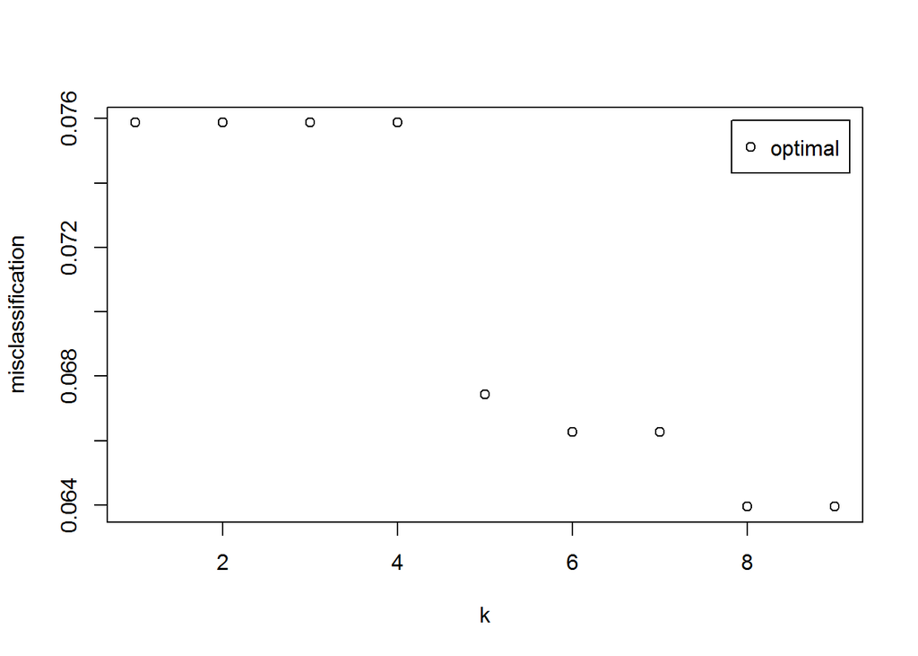

```r
plot(kneighbors)
```

The result above indicates that when k is at least 8, the misclassification is smallest, around 0.064. When k is less than 4, the misclassification is around 0.076; when k is between 5 and 7, the misclassification is around 0.068. To have least misclassification rate, k is at least 8. The larger the k, the less the noise is. Thus, k=8 is a good number to use in the nearest neighbors model.

## 9 K-nearest Neighbors - Part II

The `caret` package makes the `confusionMatrix` function ([documentation](https://artax.karlin.mff.cuni.cz/r-help/library/caret/html/confusionMatrix.html) available. The `kknn` package makes the `kknn` function available. The `e1071` package is required by the `caret` package.

```r
library(kknn)
library(caret)
library(e1071)
```

```r
Data <- csb.ren.df
head(Data, 10)
```

```
## # A tibble: 10 × 21
##       Type Family_Inc Female_perc Married_perc Fin_Indep_perc
##     <fctr>      <dbl>       <dbl>        <dbl>          <dbl>
## 1  Private   30235.73   0.5262742  0.016594232     0.12959305
## 2  Private   49731.08   0.6323897  0.103455454     0.31161532
## 3   Public   19862.04   0.6465257  0.238670695     0.89425982
## 4  Private   52681.57   0.4766449  0.132094425     0.34856856
## 5  Private   29758.64   0.6152291  0.009770889     0.14353100
## 6  Private   88316.02   0.5978236  0.059157212     0.14841398
## 7  Private   26908.71   0.6133231  0.103369066     0.39433384
## 8  Private   39822.66   0.7098014  0.360666240     0.71236387
## 9  Private   38442.71   0.6741964  0.077324066     0.27758471
## 10 Private   88069.57   0.5061189  0.025568182     0.08872378
## # ... with 16 more variables: First_Gen_perc <dbl>, Num_Branches <dbl>,
## #   Agric_deg_perc <dbl>, Nature_deg_perc <dbl>, Architect_deg_perc <dbl>,
## #   Cultural_deg_perc <dbl>, Communication_deg_perc <dbl>,
## #   Technology_deg_perc <dbl>, Cohort_def_rate <dbl>,
## #   Num_students_cohort <dbl>, Pell_grant_perc <dbl>, Deg_loan_perc <dbl>,
## #   Num_stud_median_debt <dbl>, Num_stud_cum_debt <dbl>, Cost <dbl>,
## #   new <lgl>
```

We can see that the variables are with different scales. Since we are performing the k-nearest neightbours algorithm, the distance once calculated, will determine the final prediction. If we have variables with different scales, the ones which have larger scale will influence the distance calculation in a stronger way. In order to avoid scale influences on the distance calculation, we will perform scaling of the variables.

```r
train[-1] <- scale(train[-1])

test[-1] <- scale(test[-1])

# check that we get mean of 0 and sd of 1
#colMeans(train)  # faster version of apply(scaled.dat, 2, mean)
#apply(scaled.data, 2, sd)
```

At this point we are ready to run the k-neighbours model and get predictions for the testing data set. We will first perform the knn algorithm by using the default parametrization. We will look into predicting based on 9 maximum number of neighbors.

```r
suppressWarnings(suppressMessages(library(kknn)))

model <- train.kknn(Type ~ .,
                    data = train,
                    kmax = 9,
                    response="ordinal")
model
```

```
##
## Call:
## train.kknn(formula = Type ~ ., data = train, kmax = 9, response = "ordinal")
##
## Type of response variable: nominal
## Minimal misclassification: 0.06395349
## Best kernel: optimal
## Best k: 8
```

```r
prediction <- predict(model, test)
head(prediction)
```

```
## [1] Public  Private Private Private Private Public
## Levels: Private Public
```

We will use the predicted results with the confusion matrix in order to derive the accuracy of the model.

```r
confusionMatrix(test$Type, prediction)
```

```
## Confusion Matrix and Statistics
##
##           Reference
## Prediction Private Public
##    Private     277     34
##    Public       36    513
##
##                Accuracy : 0.9186
##                  95% CI : (0.8983, 0.936)
##     No Information Rate : 0.636
##     P-Value [Acc > NIR] : <2e-16
##
##                   Kappa : 0.824
##  Mcnemar's Test P-Value : 0.9049
##
##             Sensitivity : 0.8850
##             Specificity : 0.9378
##          Pos Pred Value : 0.8907
##          Neg Pred Value : 0.9344
##              Prevalence : 0.3640
##          Detection Rate : 0.3221
##    Detection Prevalence : 0.3616
##       Balanced Accuracy : 0.9114
##
##        'Positive' Class : Private
##
```

```r
#table(testing[,1], prediction)
```

We have achieved an accuracy of 92%. The sensitivity (or the proportion of positives that are correctly identified) is 88.5% and the specificity (the proportions of negatives that are correctly identified) is 93.8%.

When plotting the missclassification against the number of the neighbours used we can see that with the increase in the number of neighbours, there is a decrease in the missclassification.

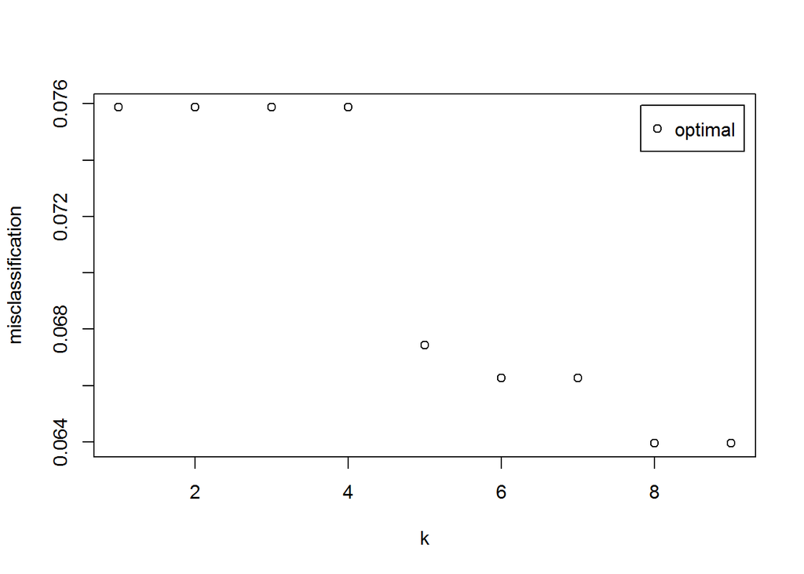

```r
plot(model)
```

The k-neighbors algorithm from the train.kknn package allows us to explore how using different kernels and different values of the kmax parameter affects the results. We are also able to see from the results which values are optimal for achieving the minimal misclassification error.

```r
suppressWarnings(suppressMessages(library(kknn)))
model <- train.kknn(Type ~ .,
                    data = train,
                    kernel = c("rectangular", "triangular", "epanechnikov", "gaussian",
    "rank", "optimal", "biweight","triweight", "cos", "inv", "optimal"),
                    kmax = 40)
model
```

```
##
## Call:
## train.kknn(formula = Type ~ ., data = train, kmax = 40, kernel = c("rectangular",     "triangular", "epanechnikov", "gaussian", "rank", "optimal",     "biweight", "triweight", "cos", "inv", "optimal"))
##
## Type of response variable: nominal
## Minimal misclassification: 0.06133721
## Best kernel: biweight
## Best k: 34
```

We can see that we get the minimum classification error when kernel = “biweight” and the maximum number of k is equal to 34.

```r
prediction <- predict(model, test)
confusionMatrix(test$Type, prediction)
```

```
## Confusion Matrix and Statistics
##
##           Reference
## Prediction Private Public
##    Private     281     30
##    Public       31    518
##
##                Accuracy : 0.9291
##                  95% CI : (0.9098, 0.9453)
##     No Information Rate : 0.6372
##     P-Value [Acc > NIR] : <2e-16
##
##                   Kappa : 0.8465
##  Mcnemar's Test P-Value : 1
##
##             Sensitivity : 0.9006
##             Specificity : 0.9453
##          Pos Pred Value : 0.9035
##          Neg Pred Value : 0.9435
##              Prevalence : 0.3628
##          Detection Rate : 0.3267
##    Detection Prevalence : 0.3616
##       Balanced Accuracy : 0.9229
##
##        'Positive' Class : Private
##
```

```r
#table(testing[,1], prediction)
```

We have achieved an accuracy of 92.9%. The sensitivity (or the proportion of positives that are correctly identified) is 90.1% and the specificity (the proportions of negatives that are correctly identified) is 94.5%.

In addition to both prameters we already discussed: kernel and the maximum number of neighbours(kmax), another parameter to explore further is the Minkowski distance. By default the distance is set to 2. We will explore how the best solution, which achieves the minimal missclassification, will change when we select a different distance. First, we will consider the case when distance is 1.

```r
suppressWarnings(suppressMessages(library(kknn)))
model <- train.kknn(Type ~ .,
                    data = train,
                    kernel = c("rectangular", "triangular", "epanechnikov", "gaussian",
    "rank", "optimal", "biweight","triweight", "cos", "inv", "optimal"),
                    kmax = 40,
                      distance = 1)
model
```

```
##
## Call:
## train.kknn(formula = Type ~ ., data = train, kmax = 40, distance = 1,     kernel = c("rectangular", "triangular", "epanechnikov", "gaussian",         "rank", "optimal", "biweight", "triweight", "cos", "inv",         "optimal"))
##
## Type of response variable: nominal
## Minimal misclassification: 0.04563953
## Best kernel: biweight
## Best k: 30
```

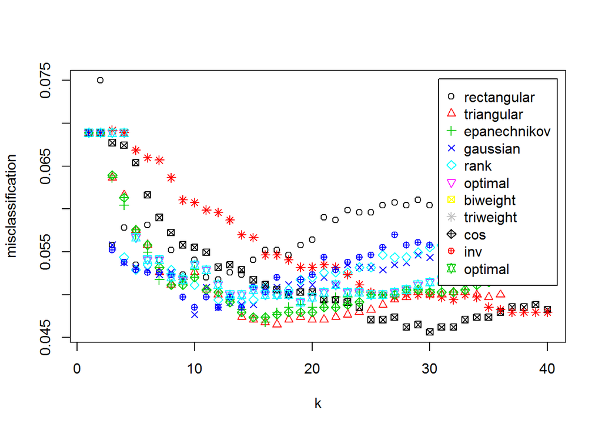

```r
plot(model)
```

We can see that in this case we get the minimum classification error when kernel = “biweight” and the maximum number of k is equal to 30 We will check the confusion matrix for this solution.

```r
prediction <- predict(model, test)
confusionMatrix(test$Type, prediction)
```

```
## Confusion Matrix and Statistics
##
##           Reference
## Prediction Private Public
##    Private     282     29
##    Public       24    525
##
##                Accuracy : 0.9384
##                  95% CI : (0.9202, 0.9535)
##     No Information Rate : 0.6442
##     P-Value [Acc > NIR] : <2e-16
##
##                   Kappa : 0.8661
##  Mcnemar's Test P-Value : 0.5827
##
##             Sensitivity : 0.9216
##             Specificity : 0.9477
##          Pos Pred Value : 0.9068
##          Neg Pred Value : 0.9563
##              Prevalence : 0.3558
##          Detection Rate : 0.3279
##    Detection Prevalence : 0.3616
##       Balanced Accuracy : 0.9346
##
##        'Positive' Class : Private
##
```

```r
#table(testing[,1], prediction)
```

We have achieved an accuracy of 93.8%. The sensitivity (or the proportion of positives that are correctly identified) is 92.2% and the specificity (the proportions of negatives that are correctly identified) is 94.8%.

As a next step, we will continue exploring how changing the Markowski distance will affect the final result. We will change the Markowski distance to 3.

```r
suppressWarnings(suppressMessages(library(kknn)))
model <- train.kknn(Type ~ .,
                    data = train,
                    kernel = c("rectangular", "triangular", "epanechnikov", "gaussian",
    "rank", "optimal", "biweight","triweight", "cos", "inv", "optimal"),
                    kmax = 40,
                      distance = 3)
model
```

```
##
## Call:
## train.kknn(formula = Type ~ ., data = train, kmax = 40, distance = 3,     kernel = c("rectangular", "triangular", "epanechnikov", "gaussian",         "rank", "optimal", "biweight", "triweight", "cos", "inv",         "optimal"))
##
## Type of response variable: nominal
## Minimal misclassification: 0.06627907
## Best kernel: biweight
## Best k: 25
```

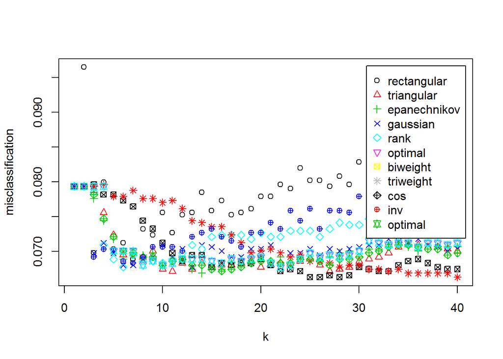

```r
plot(model)
```

We can see that in this case we get the minimum classification error when kernel = “biweight” and the maximum number of k is equal to 25. We will check the confusion matrix for this solution.

```r
prediction <- predict(model, test)
confusionMatrix(test$Type, prediction)
```

```
## Confusion Matrix and Statistics
##
##           Reference
## Prediction Private Public
##    Private     279     32
##    Public       34    515
##
##                Accuracy : 0.9233
##                  95% CI : (0.9034, 0.9402)
##     No Information Rate : 0.636
##     P-Value [Acc > NIR] : <2e-16
##
##                   Kappa : 0.834
##  Mcnemar's Test P-Value : 0.902
##
##             Sensitivity : 0.8914
##             Specificity : 0.9415
##          Pos Pred Value : 0.8971
##          Neg Pred Value : 0.9381
##              Prevalence : 0.3640
##          Detection Rate : 0.3244
##    Detection Prevalence : 0.3616
##       Balanced Accuracy : 0.9164
##
##        'Positive' Class : Private
##
```

```r
#table(testing[,1], prediction)
```

Since the Minkowski distance determines the shape which is formed by the neighbours, it is important to cover values which are smaller than 1.

We will explore next a distance which is equal to 0.35.

```r
suppressWarnings(suppressMessages(library(kknn)))
model <- train.kknn(Type ~ .,
                    data = train,
                    kernel = c("rectangular", "triangular", "epanechnikov", "gaussian",
    "rank", "optimal", "biweight","triweight", "cos", "inv", "optimal"),
                    kmax = 40,
                      distance = 0.35)
model
```

```
##
## Call:
## train.kknn(formula = Type ~ ., data = train, kmax = 40, distance = 0.35,     kernel = c("rectangular", "triangular", "epanechnikov", "gaussian",         "rank", "optimal", "biweight", "triweight", "cos", "inv",         "optimal"))
##
## Type of response variable: nominal
## Minimal misclassification: 0.04593023
## Best kernel: biweight
## Best k: 18
```

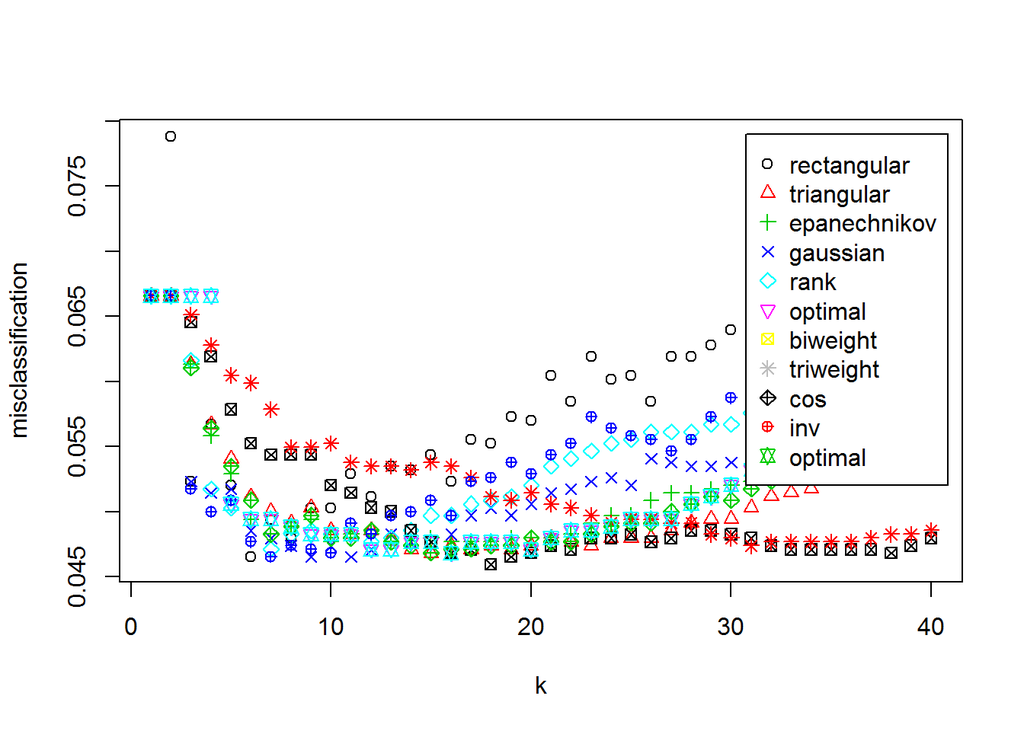

```r
plot(model)
```

We can see that in this case we get the minimum classification error when kernel = “biweight” and the maximum number of k is equal to 18. We will check the confusion matrix for this solution.

```r
prediction <- predict(model, test)
confusionMatrix(test$Type, prediction)
```

```
## Confusion Matrix and Statistics
##
##           Reference
## Prediction Private Public
##    Private     288     23
##    Public       17    532
##
##                Accuracy : 0.9535
##                  95% CI : (0.9372, 0.9666)
##     No Information Rate : 0.6453
##     P-Value [Acc > NIR] : <2e-16
##
##                   Kappa : 0.8988
##  Mcnemar's Test P-Value : 0.4292
##
##             Sensitivity : 0.9443
##             Specificity : 0.9586
##          Pos Pred Value : 0.9260
##          Neg Pred Value : 0.9690
##              Prevalence : 0.3547
##          Detection Rate : 0.3349
##    Detection Prevalence : 0.3616
##       Balanced Accuracy : 0.9514
##
##        'Positive' Class : Private
##
```

```r
#table(testing[,1], prediction)
```

We have achieved an accuracy of 95.4%. The sensitivity (or the proportion of positives that are correctly identified) is 94.4% and the specificity (the proportions of negatives that are correctly identified) is 95.9%.

Now we will explore what the results are when the distance is 0.7.

```r
suppressWarnings(suppressMessages(library(kknn)))
model <- train.kknn(Type ~ .,
                    data = train,
                    kernel = c("rectangular", "triangular", "epanechnikov", "gaussian",
    "rank", "optimal", "biweight","triweight", "cos", "inv", "optimal"),
                    kmax = 40,
                      distance = 0.7)
model
```

```
##
## Call:
## train.kknn(formula = Type ~ ., data = train, kmax = 40, distance = 0.7,     kernel = c("rectangular", "triangular", "epanechnikov", "gaussian",         "rank", "optimal", "biweight", "triweight", "cos", "inv",         "optimal"))
##
## Type of response variable: nominal
## Minimal misclassification: 0.04418605
## Best kernel: triangular
## Best k: 15
```

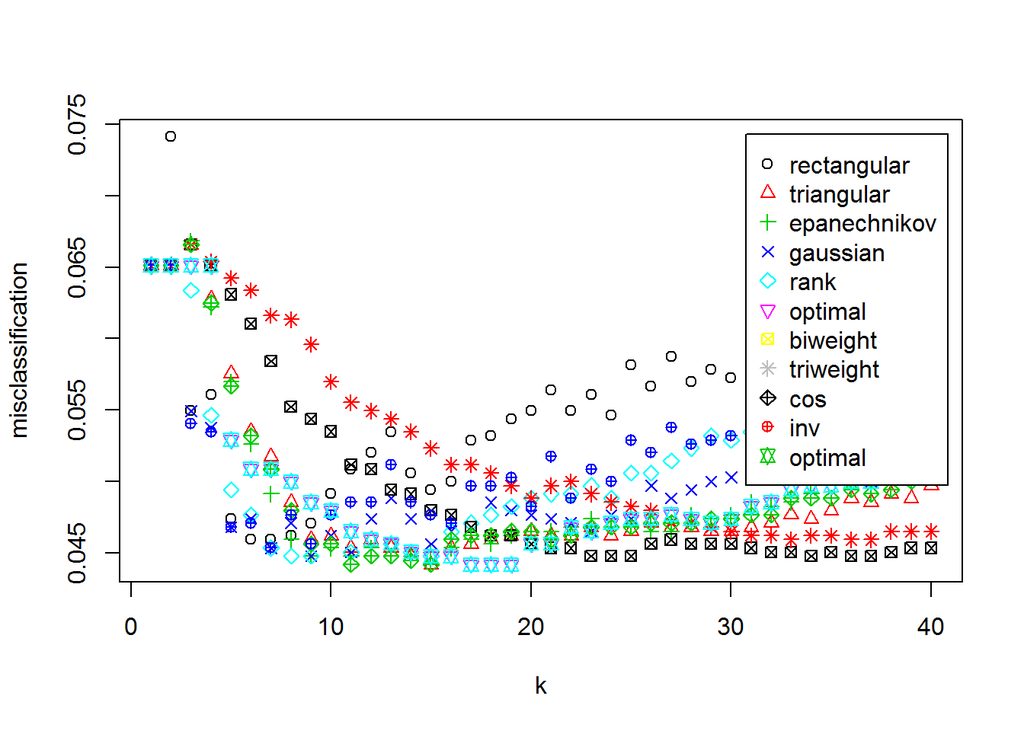

```r
plot(model)
```

We can see that in this case we get the minimum classification error when kernel = “triangular” and the maximum number of k is equal to 15. We will check the confusion matrix for this solution.

```r
prediction <- predict(model, test)
confusionMatrix(test$Type, prediction)
```

```
## Confusion Matrix and Statistics
##
##           Reference
## Prediction Private Public
##    Private     284     27
##    Public       19    530
##
##                Accuracy : 0.9465
##                  95% CI : (0.9293, 0.9606)
##     No Information Rate : 0.6477
##     P-Value [Acc > NIR] : <2e-16
##
##                   Kappa : 0.8835
##  Mcnemar's Test P-Value : 0.302
##
##             Sensitivity : 0.9373
##             Specificity : 0.9515
##          Pos Pred Value : 0.9132
##          Neg Pred Value : 0.9654
##              Prevalence : 0.3523
##          Detection Rate : 0.3302
##    Detection Prevalence : 0.3616
##       Balanced Accuracy : 0.9444
##
##        'Positive' Class : Private
##
```

```r
#table(testing[,1], prediction)
```

We have achieved an accuracy of 94.7%. The sensitivity (or the proportion of positives that are correctly identified) is 93.7% and the specificity (the proportions of negatives that are correctly identified) is 95.2%.

We can conclude that the best results are achieved when the kernel = “biweight”, the maximum number of k is equal to 18 and the Markowski distance is 0.35. the accuracy score is 95.4%.

## 10 Comparison and Conclusion

### 10.1 Optimal model

We would like to compare the best decision tree model and the K-nearest Neighbors model with the highest accuracy score we’ve built to find an optimal one in our case:

| Model | Accuracy |  |
| --- | --- | --- |
| Decision Tree | 93.6% |  |
| K-nearest Neighbors | 95.4% |  |

In our case, the optimal model that gives us the lowest missclassfication rate is the K-nearest Neighbors with the kernel = “biweight”, the maximum number of k equals to 18 and the Markowski distance is 0.35. The accuracy score reaches 95.4%.

### 10.2 Important variables for classification

From the plot of decision tree model, we could define that `Cost` (Average annual cost of attendance a college) is the most essential variable for classifying a college into Public or Private. In addition, `Female_perc` and `Fin_Indep_perc` are also very important variables for classification.

### 10.3 Conclusion

In terms of accuracy score, K-nearest Neighbors model is the optimal model in our case. However,we might choose different models based on the specific situation.

The main advantage of the decision tree model is interpretability. Decision trees are “white boxes” in the sense that the acquired knowledge can be expressed in a readable form, while KNN is generally black box, i.e. you cannot read the acquired knowledge in a comprehensible way.

In addition, KNN determines neighborhoods, so there must be a distance metric. This implies that all features must be numeric. Distance metrics may be effected by varying scales between attributes and also high-dimensional space. DT on the other hand predicts a class for a given input vector. The attributes may be numeric or nominal.

In conclusion, the decision tree is easy to interpret. However, complexity is the down side and the tree might get too large even after some pruning.

KNN is a black box, and the net model is not interpretable, but the accuracy is usually high in practice.

As a data analyst, we need to choose the proper model caerfully based on our demand.